# Project2

waheeb Algabri

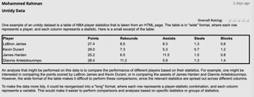

```r
knitr:: include_graphics("player.png")
```

# untidy data posted by mohammed ramadan in discussion 5

One example of an untidy dataset is a table of NBA player statistics that is taken from an HTML page. The table is in “wide” format, where each row represents a player, and each column represents a statistic.

An analysis that might be performed on this data is to compare the performance of different players based on their statistics. For example, one might be interested in comparing the points scored by LeBron James and Kevin Durant, or in comparing the assists of James Harden and Giannis Antetokounmpo. However, the wide format of the table makes it difficult to perform these comparisons, since the relevant statistics are spread out across different columns.

```r
library(RMySQL)
con <- dbConnect(MySQL(),
                 host = "localhost",
                 username = "root",
                 password = "Alex9297248844",
                 dbname = "Project2")
```

```r
con <- dbGetQuery(con, "SELECT * FROM player_stats ")
```

```r
print (con)
```

```
##   id                player points rebounds assists steals blocks
## 1  1          LeBron James   27.4      8.5     8.3    1.3    0.6
## 2  2          Kevin Durant   29.0      7.3     5.3    0.7    1.2
## 3  3          James Harden   25.2      6.5    11.5    1.5    0.8
## 4  4 Giannis Antetokounmpo   28.4     11.2     5.9    1.3    1.4
```

Tidy and transform the data

```r
# convert the data from wide format to long format

library(tidyr)

df <- con %>%
  pivot_longer(cols = c("points", "rebounds", "assists", "steals", "blocks"),
               names_to = "statistic",
               values_to = "value")
```

```r
print(df)
```

```
## # A tibble: 20 × 4
##       id player                statistic value
##    <int> <chr>                 <chr>     <dbl>
##  1     1 LeBron James          points     27.4
##  2     1 LeBron James          rebounds    8.5
##  3     1 LeBron James          assists     8.3
##  4     1 LeBron James          steals      1.3
##  5     1 LeBron James          blocks      0.6
##  6     2 Kevin Durant          points     29
##  7     2 Kevin Durant          rebounds    7.3
##  8     2 Kevin Durant          assists     5.3
##  9     2 Kevin Durant          steals      0.7
## 10     2 Kevin Durant          blocks      1.2
## 11     3 James Harden          points     25.2
## 12     3 James Harden          rebounds    6.5
## 13     3 James Harden          assists    11.5
## 14     3 James Harden          steals      1.5
## 15     3 James Harden          blocks      0.8
## 16     4 Giannis Antetokounmpo points     28.4
## 17     4 Giannis Antetokounmpo rebounds   11.2
## 18     4 Giannis Antetokounmpo assists     5.9
## 19     4 Giannis Antetokounmpo steals      1.3
## 20     4 Giannis Antetokounmpo blocks      1.4
```

using dplyr to filter the data and compare the points scored by LeBron James and Kevin Duran

```r
library(dplyr)

df %>%
  filter(player %in% c("LeBron James", "Kevin Durant"), statistic == "points") %>%
  select(player, value)
```

```
## # A tibble: 2 × 2
##   player       value
##   <chr>        <dbl>
## 1 LeBron James  27.4
## 2 Kevin Durant  29
```

bar charts to compare the mean values of different statistics for each player

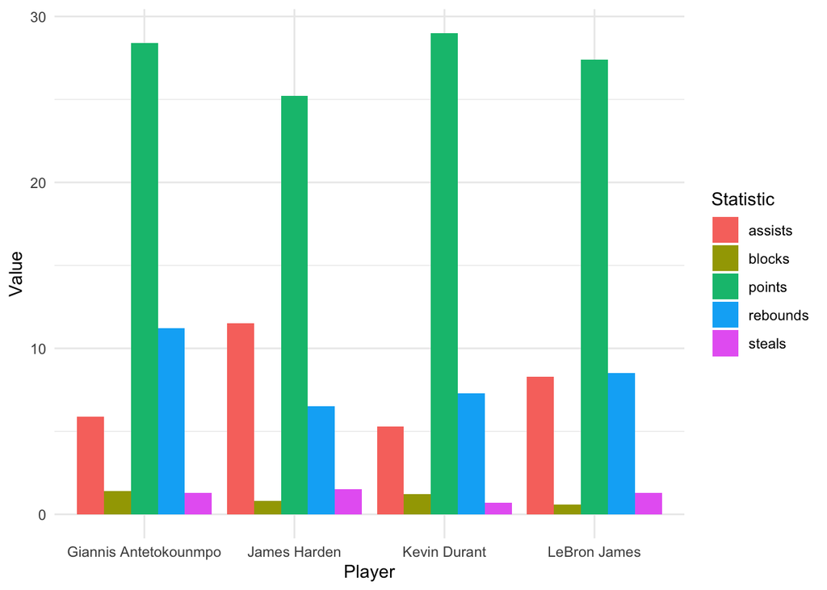

```r
library(ggplot2)

ggplot(df, aes(x = player, y = value, fill = statistic)) +
  geom_bar(stat = "identity", position = "dodge") +
  labs(x = "Player", y = "Value", fill = "Statistic") +
  theme_minimal()
```

box plots to compare the distribution of different statistics for each player

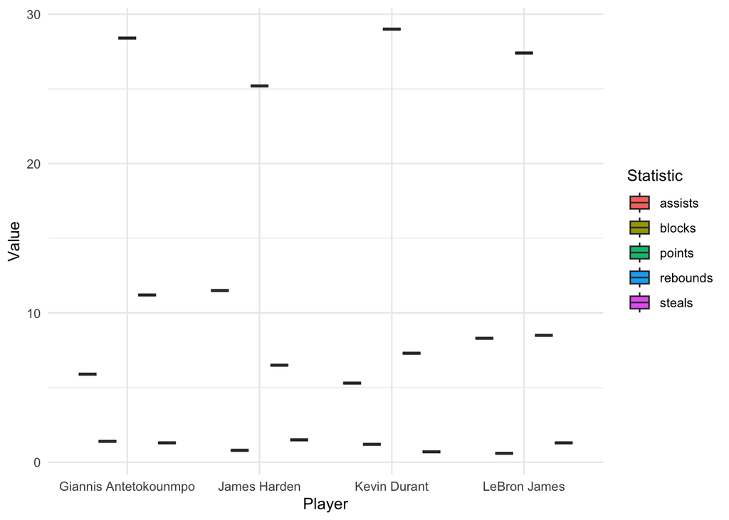

```r
ggplot(df, aes(x = player, y = value, fill = statistic)) +
  geom_boxplot() +
  labs(x = "Player", y = "Value", fill = "Statistic") +
  theme_minimal()
```

```r
# Filter the data to include only LeBron James and Kevin Durant
data_subset <- df %>%
  filter(player %in% c("LeBron James", "Kevin Durant"))

# Perform a two-sample t-test to compare the mean points scored between the two players
t.test(value ~ player, data = data_subset, var.equal = TRUE)
```

```
##
##  Two Sample t-test
##
## data:  value by player
## t = -0.073002, df = 8, p-value = 0.9436
## alternative hypothesis: true difference in means between group Kevin Durant and group LeBron James is not equal to 0
## 95 percent confidence interval:
##  -16.94587  15.90587
## sample estimates:
## mean in group Kevin Durant mean in group LeBron James
##                       8.70                       9.22
```

the p-value of 0.94 suggests that there is not a significant difference in the means of the two groups, and the confidence interval (-16.95, 15.91) includes zero, which also supports this conclusion.

# Untidy data posted by Coco Donovan in discussion 5

sources: [untidy data](https://towardsdatascience.com/whats-tidy-data-how-to-organize-messy-datasets-in-python-with-melt-and-pivotable-functions-5d52daa996c9)

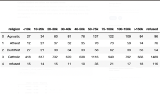

```r
knitr:: include_graphics("coco.png")
```

As far as analysis goes you could group by religion and see what the religious makeup of all respondents was by percentages. This is also just an idea, but it could be helpful to conduct a visual analysis with parallel bar charts to get and idea of which religion has the wealthiest followers (based solely on the results of this data)

##### Data cleanup

```r
library(RMySQL)
# Connect to the database using the environment variables
coco<- dbConnect(MySQL(),
                 host = "localhost",
                 username = "root",
                 password = "Alex9297248844",
                 dbname = "Project2")
```

```r
coco <- dbGetQuery(coco, "SELECT * from religion_survey")
```

```r
knitr::kable(coco)
```

| id | religion | lt_10k | _10_20k | _20_30k | _30_40k | _40_50k | _50_75k | _75_100k | _100_150k | gt_150k | refused |
| --- | --- | --- | --- | --- | --- | --- | --- | --- | --- | --- | --- |
| 1 | Agnostic | 27 | 34 | 60 | 81 | 76 | 134 | 122 | 109 | 84 | 96 |
| 2 | Atheist | 12 | 27 | 37 | 52 | 35 | 70 | 73 | 59 | 74 | 76 |
| 3 | Buddhist | 27 | 21 | 30 | 34 | 33 | 58 | 62 | 39 | 53 | 54 |
| 4 | Catholic | 418 | 617 | 732 | 670 | 638 | 1116 | 949 | 792 | 633 | 1489 |
| 5 | Refused | 15 | 14 | 15 | 11 | 10 | 35 | 21 | 17 | 18 | 116 |

##### Tidy and transform the data using tidyr and dplyr

```r
library(tidyverse)
library(dplyr)
```

drop id column

```r
coco_new <- select(coco, -id)
```

```r
knitr::kable(coco_new)
```

| religion | lt_10k | _10_20k | _20_30k | _30_40k | _40_50k | _50_75k | _75_100k | _100_150k | gt_150k | refused |
| --- | --- | --- | --- | --- | --- | --- | --- | --- | --- | --- |
| Agnostic | 27 | 34 | 60 | 81 | 76 | 134 | 122 | 109 | 84 | 96 |
| Atheist | 12 | 27 | 37 | 52 | 35 | 70 | 73 | 59 | 74 | 76 |
| Buddhist | 27 | 21 | 30 | 34 | 33 | 58 | 62 | 39 | 53 | 54 |
| Catholic | 418 | 617 | 732 | 670 | 638 | 1116 | 949 | 792 | 633 | 1489 |
| Refused | 15 | 14 | 15 | 11 | 10 | 35 | 21 | 17 | 18 | 116 |

##### Convert the data from wide format to long format using

```r
coco_tidy <- coco_new %>%
  pivot_longer(cols = -religion, names_to = "income_level", values_to = "count") %>%
  mutate(income_level = gsub("income_", "", income_level)) %>%
  arrange(religion, income_level)

head (coco_tidy)
```

```
## # A tibble: 6 × 3
##   religion income_level count
##   <chr>    <chr>        <int>
## 1 Agnostic _100_150k      109
## 2 Agnostic _10_20k         34
## 3 Agnostic _20_30k         60
## 4 Agnostic _30_40k         81
## 5 Agnostic _40_50k         76
## 6 Agnostic _50_75k        134
```

```r
summary(coco_tidy)
```

```
##    religion         income_level           count
##  Length:50          Length:50          Min.   :  10.00
##  Class :character   Class :character   1st Qu.:  27.75
##  Mode  :character   Mode  :character   Median :  58.50
##                                        Mean   : 201.50
##                                        3rd Qu.: 114.25
##                                        Max.   :1489.00
```

Replace all occurrences of “refused” in the income_level column with NA, creating a tidy dataset where all values are of the same type and format.

```r
coco_tidy <- coco_tidy %>%
  mutate(income_level = replace(income_level, income_level == "refused", NA))
```

```r
head(coco_tidy)
```

```
## # A tibble: 6 × 3
##   religion income_level count
##   <chr>    <chr>        <int>
## 1 Agnostic _100_150k      109
## 2 Agnostic _10_20k         34
## 3 Agnostic _20_30k         60
## 4 Agnostic _30_40k         81
## 5 Agnostic _40_50k         76
## 6 Agnostic _50_75k        134
```

```r
library(dplyr)
library(ggplot2)

# group data by religion and income level, calculate percentage of respondents
data_summary <- coco_tidy %>%
  group_by(religion, income_level) %>%
  summarize(count = sum(count)) %>%
  mutate(percent = count/sum(count) * 100)
```

```r
head(data_summary)
```

```
## # A tibble: 6 × 4
## # Groups:   religion [1]
##   religion income_level count percent
##   <chr>    <chr>        <int>   <dbl>
## 1 Agnostic _100_150k      109   13.2
## 2 Agnostic _10_20k         34    4.13
## 3 Agnostic _20_30k         60    7.29
## 4 Agnostic _30_40k         81    9.84
## 5 Agnostic _40_50k         76    9.23
## 6 Agnostic _50_75k        134   16.3
```

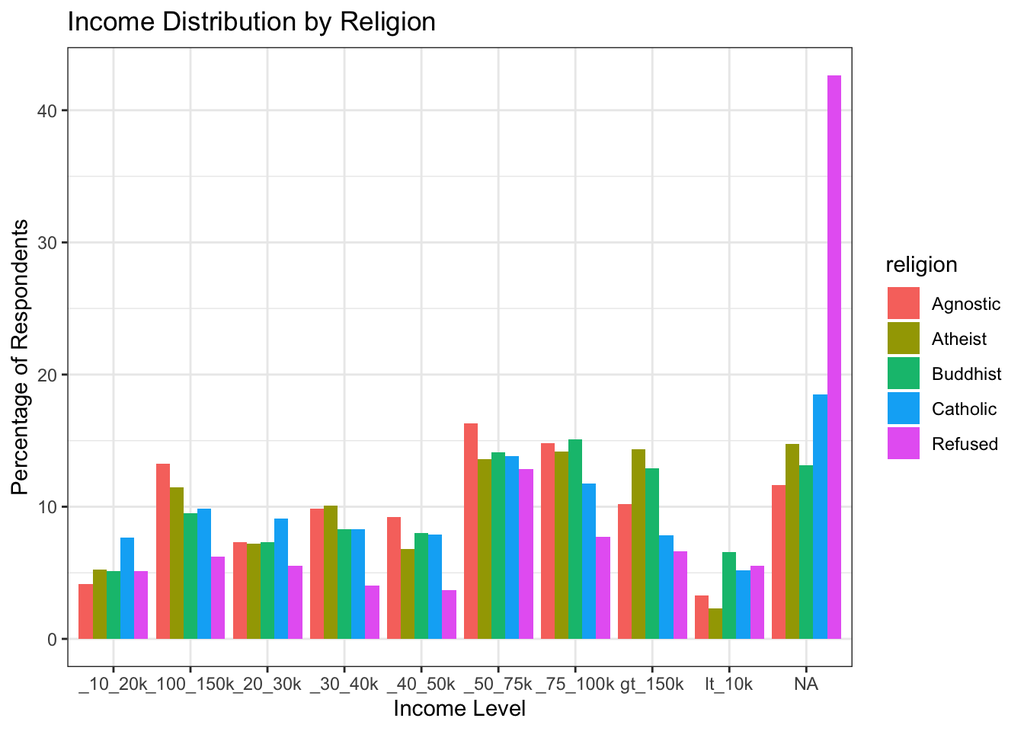

```r
# create parallel bar chart
ggplot(data_summary, aes(x = income_level, y = percent, fill = religion)) +
  geom_bar(stat = "identity", position = "dodge") +
  labs(title = "Income Distribution by Religion",
       x = "Income Level", y = "Percentage of Respondents") +
  theme_bw()
```

```r
summary(data_summary)
```

```
##    religion         income_level           count            percent
##  Length:50          Length:50          Min.   :  10.00   Min.   : 2.330
##  Class :character   Class :character   1st Qu.:  27.75   1st Qu.: 6.581
##  Mode  :character   Mode  :character   Median :  58.50   Median : 8.704
##                                        Mean   : 201.50   Mean   :10.000
##                                        3rd Qu.: 114.25   3rd Qu.:13.078
##                                        Max.   :1489.00   Max.   :42.647
```

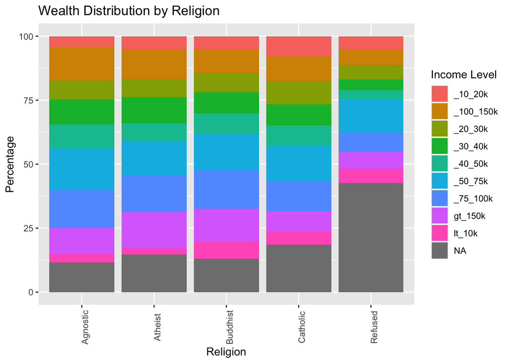

```r
# Create the stacked bar chart
ggplot(data_summary, aes(x = religion, y = percent, fill = income_level)) +
  geom_bar(stat = "identity", position = "stack") +
  theme(axis.text.x = element_text(angle = 90)) +
  labs(title = "Wealth Distribution by Religion", x = "Religion", y = "Percentage", fill = "Income Level")
```

# Untidy data posted by Farhana Akther in discussion 5

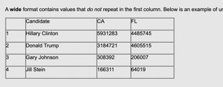

```r
knitr:: include_graphics("Farhana.png")
```

The table above reports vote counts for two US states, California and Florida. In this table, the column names CA and FL are values of the variable state. Therefore, we can say that this table is in an untidy format.

As per analysis, we can compare the vote counts in each state vs candidate. We can also “melt” the table and transform into a long format and tidy the table so that further analysis can be done; including plotting functions, hypothesis testing functions, and modeling functions such as linear regression.

[Source](https://gagneurlab.github.io/dataviz/tidy-data-and-combining-tables.html)

##### Data cleanup

```r
library(RMySQL)
Farhana<- dbConnect(MySQL(),
                 host = "localhost",
                 username = "root",
                 password = "Alex9297248844",
                 dbname = "Project2")
```

```r
Farhana <- dbGetQuery(Farhana, "SELECT * FROM election_results ")
```

```r
knitr::kable(Farhana)
```

| candidate | CA | FL |
| --- | --- | --- |
| Donald Trump | 3184721 | 4605515 |
| Gary Johnson | 308392 | 206007 |
| Hillary Clinton | 5931283 | 4485745 |
| Jill Stein | 166311 | 64019 |

Upload requied packages

```r
library(tidyverse)
library(dplyr)
```

##### Convert the data from wide to long format

```r
election_data <-Farhana %>%
  pivot_longer(cols = c(CA, FL), names_to = "state", values_to = "votes")
```

```r
knitr::kable(election_data)
```

| candidate | state | votes |
| --- | --- | --- |
| Donald Trump | CA | 3184721 |
| Donald Trump | FL | 4605515 |
| Gary Johnson | CA | 308392 |
| Gary Johnson | FL | 206007 |
| Hillary Clinton | CA | 5931283 |
| Hillary Clinton | FL | 4485745 |
| Jill Stein | CA | 166311 |
| Jill Stein | FL | 64019 |

##### Analysis

Calculate the total votes for each candidate

```r
total_votes <- election_data %>%
  group_by(candidate) %>%
  summarize(total_votes = sum(votes))
```

Join the total votes to the long format data frame

```r
long_election_data <- election_data %>%
  left_join(total_votes, by = "candidate")
```

```r
knitr::kable(long_election_data)
```

| candidate | state | votes | total_votes |
| --- | --- | --- | --- |
| Donald Trump | CA | 3184721 | 7790236 |
| Donald Trump | FL | 4605515 | 7790236 |
| Gary Johnson | CA | 308392 | 514399 |
| Gary Johnson | FL | 206007 | 514399 |
| Hillary Clinton | CA | 5931283 | 10417028 |
| Hillary Clinton | FL | 4485745 | 10417028 |
| Jill Stein | CA | 166311 | 230330 |
| Jill Stein | FL | 64019 | 230330 |

Bar plot of the vote counts for each candidate in each state

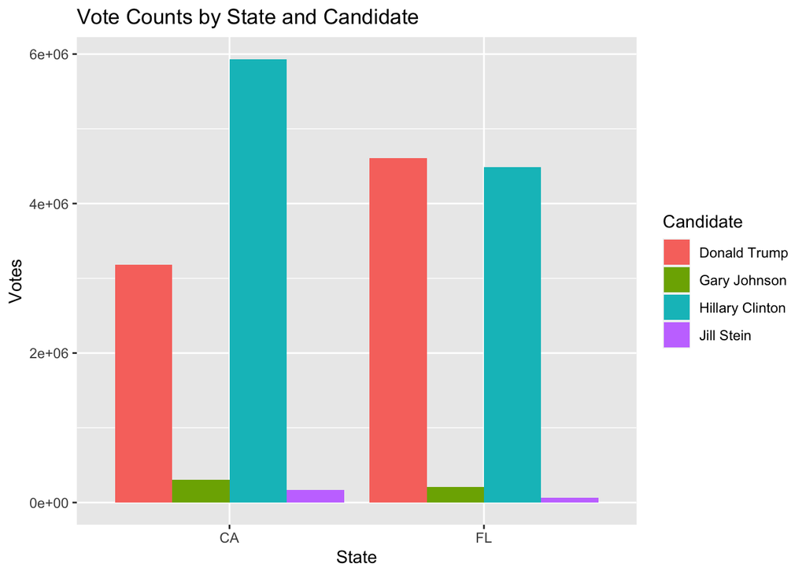

```r
library(ggplot2)

ggplot(long_election_data, aes(x = state, y = votes, fill = candidate)) +
  geom_col(position = "dodge") +
  labs(title = "Vote Counts by State and Candidate",
       x = "State", y = "Votes",
       fill = "Candidate")
```

```r
summary(long_election_data)
```

```
##   candidate            state               votes          total_votes
##  Length:8           Length:8           Min.   :  64019   Min.   :  230330
##  Class :character   Class :character   1st Qu.: 196083   1st Qu.:  443382
##  Mode  :character   Mode  :character   Median :1746556   Median : 4152318
##                                        Mean   :2368999   Mean   : 4737998
##                                        3rd Qu.:4515688   3rd Qu.: 8446934
##                                        Max.   :5931283   Max.   :10417028
```

I will use linear regression to model the relationship between the vote counts for each candidate in California and Florida:

```r
# Fit a linear regression model to the data
lm_model <- lm(votes ~ state + candidate, data = long_election_data)

# View the model summary
summary(lm_model)
```

```
##
## Call:
## lm(formula = votes ~ state + candidate, data = long_election_data)
##
## Residuals:
##       1       2       3       4       5       6       7       8
## -739075  739075   22515  -22515  694091 -694091   22468  -22468
##
## Coefficients:
##                          Estimate Std. Error t value Pr(>|t|)
## (Intercept)               3923796     654792   5.992  0.00931 **
## stateFL                    -57355     585664  -0.098  0.92816
## candidateGary Johnson    -3637918     828254  -4.392  0.02187 *
## candidateHillary Clinton  1313396     828254   1.586  0.21098
## candidateJill Stein      -3779953     828254  -4.564  0.01973 *
## ---
## Signif. codes:  0 '***' 0.001 '**' 0.01 '*' 0.05 '.' 0.1 ' ' 1
##
## Residual standard error: 828300 on 3 degrees of freedom
## Multiple R-squared:  0.9509, Adjusted R-squared:  0.8855
## F-statistic: 14.53 on 4 and 3 DF,  p-value: 0.02639
```